# Portfolio1

KechenLu

# Load dataset

```r
library(ggplot2)
library(dplyr)
joined_data= read.csv("C:/Users/27977/Downloads/433/joined_data.csv")
```

## Introduction:

### I choose the dataset containing the unemployment rate, gdp and education level of each state in the US. It combines different categories of data from multiple aspects of the US. This dataset is interesting because the information is comprehensive, crossing from education to unemployment rate to reflect the true aspect of the US from a data perspective. These data are recorded on a monthly basis from Dec, 2020 to Nov. 2021, thus given a time span of development through data visualization.

```r
head(joined_data)
```

```
##   X year_mon      state Administered_Dose1_Pop_Pct Series_Complete_Pop_Pct
## 1 1 Dec 2020    Alabama                          0                       0
## 2 2 Dec 2020     Alaska                          0                       0
## 3 3 Dec 2020    Arizona                          0                       0
## 4 4 Dec 2020   Arkansas                          0                       0
## 5 5 Dec 2020 California                          0                       0
## 6 6 Dec 2020   Colorado                          0                       0
##   value Population_over_25 High_School_or_Higher_Population
## 1 50536            3360058                          2926985
## 2 77640             484058                           452968
## 3 58945            4944540                          4331542
## 4 47597            2036456                          1781463
## 5 75235           26937872                         22636359
## 6 72331            3974943                          3672723
##   High_School_or_Higher_Pct Bachelor_or_Higher_Population
```

[output cut: 34 more lines]

# Create the first graph

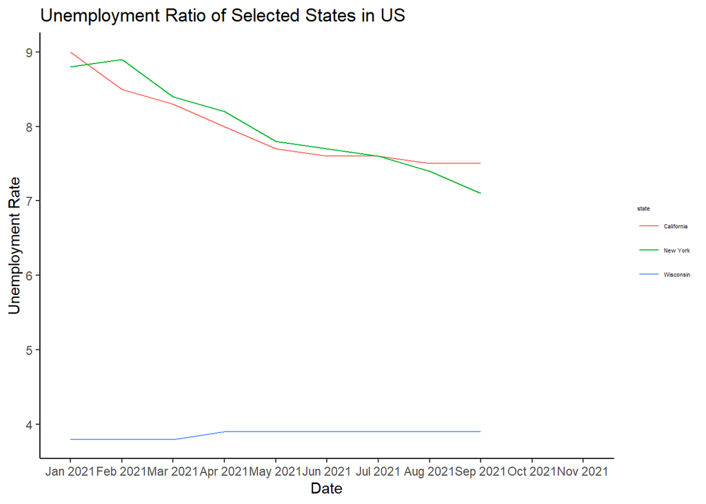

```r
new=joined_data %>%
  filter(state==("Wisconsin")|state==("California")|state==("New York"))%>%
  filter(grepl("2021", year_mon))
new%>%
  mutate(year_mon =ordered(year_mon, levels = unique(year_mon))) %>%
  ggplot(aes(x=year_mon, y=unemployment_rate, group = state,colour=state))+
  geom_line()+
  theme_classic()+
  xlab("Date")+
  ylab("Unemployment Rate")+
  ggtitle("Unemployment Ratio of Selected States in US")+
  theme(legend.title = element_text(size=4),legend.text=element_text(size=4))
```

```r
  # ggplot(aes(x=year_mon, y=unemployment_rate, group = state,colour=state))+
  # geom_line()+
  # theme_classic()+
  # xlab("Date")+
  # ylab("Unemployment Rate")+
  # ggtitle("Unemployment Ratio of Each State in US")+
  # theme(legend.title = element_text(size=4),legend.text=element_text(size=4))
  # scale_x_discrete(limits = c("Dec 2020","Jan 2021",))
```